# Project: Investigate a Dataset (Replace this with something more specific!)

## Exploratory Data Analysis

> **Tip**: Now that you've trimmed and cleaned your data, you're ready to move on to exploration. Compute statistics and create visualizations with the goal of addressing the research questions that you posed in the Introduction section. It is recommended that you be systematic with your approach. Look at one variable at a time, and then follow it up by looking at relationships between variables.

### Research Question 1 :1- what trend of movies based on runtimes, popularity and revenues over years?

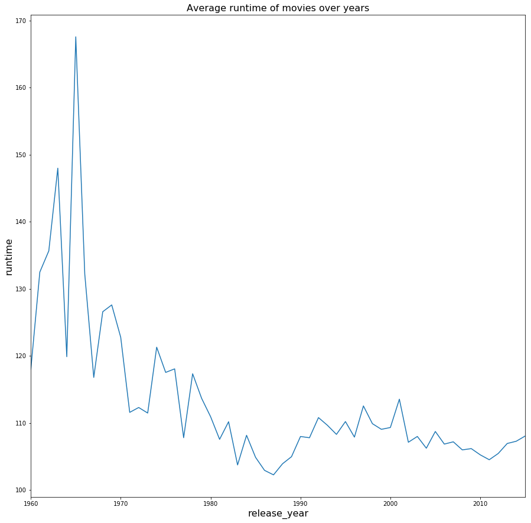

```python
# Use this, and more code cells, to explore your data. Don't forget to add
#   Markdown cells to document your observations and findings.
df_TMDb.groupby('release_year')['runtime'].mean().plot(kind = 'line', figsize = (15, 15))
plt.title('Average runtime of movies over years', fontsize = 16)
plt.xlabel('release_year', fontsize = 16)
plt.ylabel('runtime', fontsize = 16);
```

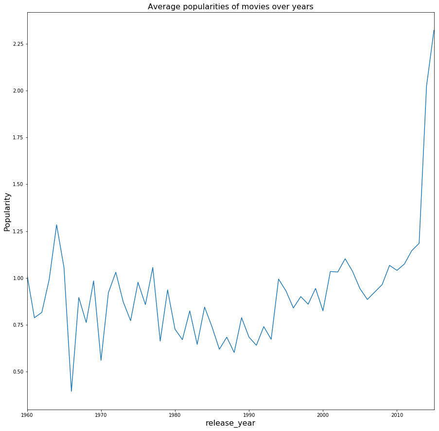

```python
df_TMDb.groupby('release_year')['popularity'].mean().plot(kind = 'line', figsize = (15, 15))
plt.title('Average popularities of movies over years', fontsize = 16)
plt.xlabel('release_year', fontsize = 16)
plt.ylabel('Popularity', fontsize = 16);
```

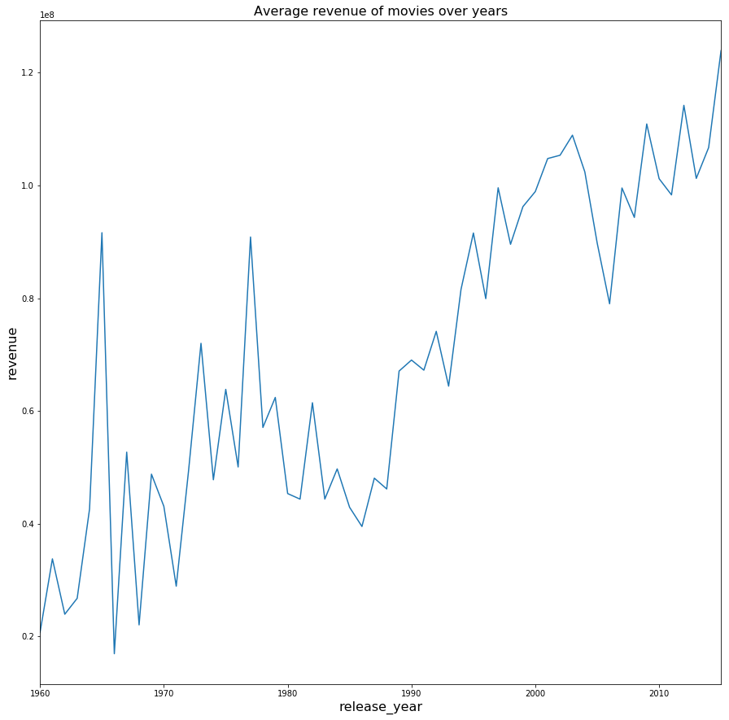

```python
df_TMDb.groupby('release_year')['revenue'].mean().plot(kind = 'line', figsize = (15, 15))
plt.title('Average revenue of movies over years', fontsize = 16)
plt.xlabel('release_year', fontsize = 16)
plt.ylabel('revenue', fontsize = 16);
```

### Research Question 2 (what is the highest revenue of movies over years?)

```python
# Continue to explore the data to address your additional research
#   questions. Add more headers as needed if you have more questions to
#   investigate.
df_TMDb.sort_values('revenue', ascending = False).head(1)
```

|  | popularity | budget | revenue | original_title | runtime | release_date | vote_count | vote_average | release_year | budget_adj | revenue_adj |
| --- | --- | --- | --- | --- | --- | --- | --- | --- | --- | --- | --- |
| 1386 | 9.432768 | 237000000 | 2781505847 | Avatar | 162 | 12/10/09 | 8458 | 7.1 | 2009 | 2.408869e+08 | 2.827124e+09 |

### Research Question 3 ( what is favorite movies over years?)

```python
# Continue to explore the data to address your additional research
#   questions. Add more headers as needed if you have more questions to
#   investigate.
df_TMDb.sort_values('vote_average', ascending = False).head(1)
```

|  | popularity | budget | revenue | original_title | runtime | release_date | vote_count | vote_average | release_year | budget_adj | revenue_adj |
| --- | --- | --- | --- | --- | --- | --- | --- | --- | --- | --- | --- |
| 4178 | 7.192039 | 25000000 | 28341469 | The Shawshank Redemption | 142 | 9/10/94 | 5754 | 8.4 | 1994 | 3.677779e+07 | 4.169346e+07 |

### Research Question 4 (what is count of movies for each year?)

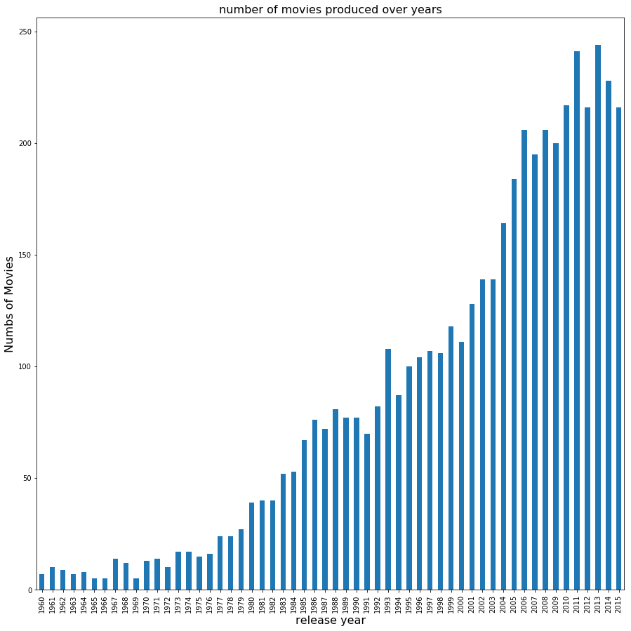

```python
df_TMDb.groupby('release_year')['release_year'].count().plot(kind = 'bar', figsize = (15, 15))
plt.title('number of movies produced over years', fontsize = 16)
plt.xlabel('release year', fontsize = 16)
plt.ylabel('Numbs of Movies', fontsize = 16);
```

### Research Question 5 ( comparing revenue with revenue adjustment)

[figure not shown]

```python
#year=df_TMDb['release_year']
#revn=df_TMDb['revenue'].mean()
#revn_adj=df_TMDb['revenue_adj'].mean()
#df.plot(x=df.index, y=df.columns)
#ax =df_TMDb.plot(x=['release_year'],y=kind='line', title ="V comp", figsize=(15, 10), legend=True, fontsize=12)
#ax.set_xlabel("release year", fontsize=12)
#ax.set_ylabel("revenues", fontsize=12)

year=df_TMDb['release_year']
revn=df_TMDb['revenue']
revn_adj=df_TMDb['revenue_adj']
df = pd.DataFrame({'revn': revn, 'revn_adj': revn_adj}, index=year)
ax = df.plot.bar(rot=0,figsize=(15, 10))
```

## Submitting your Project

> Before you submit your project, you need to create a .html or .pdf version of this notebook in the workspace here. To do that, run the code cell below. If it worked correctly, you should get a return code of 0, and you should see the generated .html file in the workspace directory (click on the orange Jupyter icon in the upper left).

> Alternatively, you can download this report as .html via the **File** > **Download as** submenu, and then manually upload it into the workspace directory by clicking on the orange Jupyter icon in the upper left, then using the Upload button.

> Once you've done this, you can submit your project by clicking on the "Submit Project" button in the lower right here. This will create and submit a zip file with this .ipynb doc and the .html or .pdf version you created. Congratulations!

```python
from subprocess import call
call(['python', '-m', 'nbconvert', 'Investigate_a_Dataset.ipynb'])
```